# 泰坦尼克号

## 有哪些因素会让船上的人死亡率更高？

### 三个因素来分析:

> 1.Pclass：船票类型（社会经济地位的代表）是否影响；

> 2.Age：年龄是否影响；

> 3.SibSp：结合船票类型和家庭关系是否影响；

# 二、数据整理阶段

## 熟悉数据后，我需整理数据如下：

> 2.将字段里的值的字符型转整型；

```python
# 导入相关库
import unicodecsv
import pandas as pd
import numpy as np
%matplotlib inline
```

```python
# 获取泰坦尼克号的数据。
titanic_datas = pd.read_csv('titanic-data.csv')
```

```python
# 查看缺失字段；
titanic_datas.info()
```

[output not shown]

## 从数据列看到 Age 和 Cabin 两个字段有缺失值，这里我们只填充Age。

```python
# 求Age的平均值填充缺失值。
mean_age=titanic_datas['Age'].mean()
titanic_datas['Age'].fillna(mean_age,inplace=True)
titanic_datas.describe()
```

|  | PassengerId | Survived | Pclass | Age | SibSp | Parch | Fare |
| --- | --- | --- | --- | --- | --- | --- | --- |
| count | 891.000000 | 891.000000 | 891.000000 | 891.000000 | 891.000000 | 891.000000 | 891.000000 |
| mean | 446.000000 | 0.383838 | 2.308642 | 29.699118 | 0.523008 | 0.381594 | 32.204208 |
| std | 257.353842 | 0.486592 | 0.836071 | 13.002015 | 1.102743 | 0.806057 | 49.693429 |
| min | 1.000000 | 0.000000 | 1.000000 | 0.420000 | 0.000000 | 0.000000 | 0.000000 |
| 25% | 223.500000 | 0.000000 | 2.000000 | 22.000000 | 0.000000 | 0.000000 | 7.910400 |
| 50% | 446.000000 | 0.000000 | 3.000000 | 29.699118 | 0.000000 | 0.000000 | 14.454200 |
| 75% | 668.500000 | 1.000000 | 3.000000 | 35.000000 | 1.000000 | 0.000000 | 31.000000 |
| max | 891.000000 | 1.000000 | 3.000000 | 80.000000 | 8.000000 | 6.000000 | 512.329200 |

## 该摘要表是我使用年龄的平均值来填充缺失值后计算的结果。

# 三、数据探索阶段

## 1. 假设经济地位越低，死亡率就越高。(船票类型1为最高地位)

```python
# 1.显示所有字段摘要数据。
titanic_datas_df.describe()
```

|  | PassengerId | Survived | Pclass | Age | SibSp | Parch | Fare |
| --- | --- | --- | --- | --- | --- | --- | --- |
| count | 891.000000 | 891.000000 | 891.000000 | 891.000000 | 891.000000 | 891.000000 | 891.000000 |
| mean | 446.000000 | 0.383838 | 2.308642 | 29.699118 | 0.523008 | 0.381594 | 32.204208 |
| std | 257.353842 | 0.486592 | 0.836071 | 13.002015 | 1.102743 | 0.806057 | 49.693429 |
| min | 1.000000 | 0.000000 | 1.000000 | 0.420000 | 0.000000 | 0.000000 | 0.000000 |
| 25% | 223.500000 | 0.000000 | 2.000000 | 22.000000 | 0.000000 | 0.000000 | 7.910400 |
| 50% | 446.000000 | 0.000000 | 3.000000 | 29.699118 | 0.000000 | 0.000000 | 14.454200 |
| 75% | 668.500000 | 1.000000 | 3.000000 | 35.000000 | 1.000000 | 0.000000 | 31.000000 |
| max | 891.000000 | 1.000000 | 3.000000 | 80.000000 | 8.000000 | 6.000000 | 512.329200 |

### 以上表分析：

> 因为年龄越大，求生欲望和求生能力就越低。我们先来证明类型3是否死亡率最高，再证明是不是年龄越大死亡率越高。

```python
# 获取已死亡数。
deceased_passenger_df = titanic_datas_df[titanic_datas_df.Survived==0]
len(deceased_passenger_df)
```

```
549
```

```python
# 获取3种船票类型的总数。
def passenger_count(data,name):
    return data.groupby(name)['PassengerId'].count()


# 计算死亡率：船票类型为1的死亡人数 除以 船票类型为1的总人数 = 船票类型为1的死亡率。
def deceased_rate(name):
    total_passenger_count = passenger_count(titanic_datas_df, name)
    num_deceased = passenger_count(deceased_passenger_df, name)
    return num_deceased / total_passenger_count


# 柱状图
def histogram(data, title):
    bar = data.plot.bar(title=title)
```

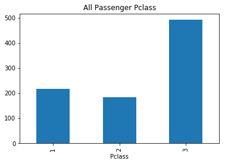

```python
# 显示3个船票类型的各自总人数
histogram(passenger_count(titanic_datas_df,'Pclass'), 'All Passenger Pclass')
```

## 总人口数角度分析：

### 接下来我使用：各船票类型的死亡数/各船票类型的人口总数=各船票类型的死亡率

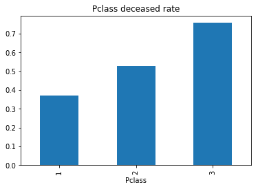

```python
# 使用直方图。
histogram(deceased_rate('Pclass'), 'Pclass deceased rate')
```

### 经济地位代表最高为舱位类型1，其次为类型2，最后类型3。从数据看舱位类型3的死亡率最高，也是人最多的航位。之前的设想是成立的，现在我们来看年龄分析。

## 2. 假设年龄越高，死亡率就越高

```python
# 将所有的年龄数据组合，例如：0-10，10-20等等。
bins = np.arange(0,90,10)
titanic_datas_df['Age_group'] = pd.cut(titanic_datas_df['Age'], bins)
```

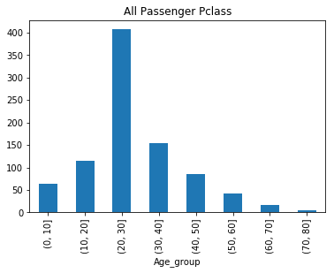

```python
# 直方图显示数据。
histogram(passenger_count(titanic_datas_df, 'Age_group'), 'All Passenger Pclass')
```

### 下面我们看所有组的死亡人数和生存人数。

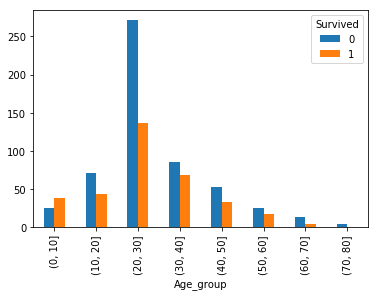

```python
# 按照['Age_group', 'Survived']进行组合，并使用直方图显示。
titanic_datas_df.groupby(['Age_group', 'Survived'])['Survived'].count().unstack().plot(kind='bar')
```

### 死亡数角度分析：

> 最多死亡数 ：20 - 30岁 ；

> 最低死亡数 ：70 - 80岁 ；

### 20 - 30岁的人数最多，死亡人数和生存人数也是最多。

### 接下来我们来看各组死亡率。

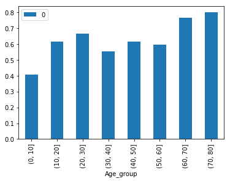

```python
# 计算死亡率和生存率，并直方图显示。
titanic_datas_df.groupby(['Age_group'])['Survived'].count()
num_Survived = titanic_datas_df.groupby(['Age_group', 'Survived'])['Survived'].count()
all_Survived = titanic_datas_df.groupby(['Age_group'])['Survived'].count()
compare_Survived = num_Survived/all_Survived
compare_Survived.unstack().plot(kind='bar',y=0)
```

### 死亡率角度分析：

> 死亡率最低： 0 - 10岁；

### 50岁以上人数少，可比性不强；我们看0岁到50岁的区域，发现不能有力证明年龄越大，死亡率越高。不能排除0岁到30岁是上升趋势，所以多少有点影响。

### 到目前为止我们已确定船票类型、年龄影响死亡率，现在我将影响因素较为明显的船票类型结合家庭关系来看死亡率变化。

## 3. 船票类型和家庭关系分析。

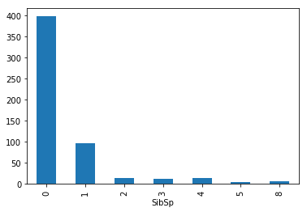

```python
# 显示已故的家庭关系的数目
deceased_passenger_df.groupby(['SibSp'])['Survived'].count().plot(kind='bar')
```

### 人数分析：

> 0：无家庭关系；

> 1：1个家庭关系； 2：2个家庭关系；以此类推...

### 数据显示，0个家庭关系为最多，5个家庭关系为最少。

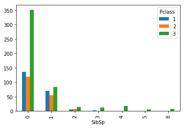

```python
# 显示各船票类型的家庭关系图。
titanic_datas_df.groupby(['SibSp','Pclass'])['Survived'].count().unstack().plot(kind='bar')
```

### 人数分析：

> 最多人数：拥有0个家庭关系并持船票类型3。

> 较少人数：分别是3到8个家庭关系。

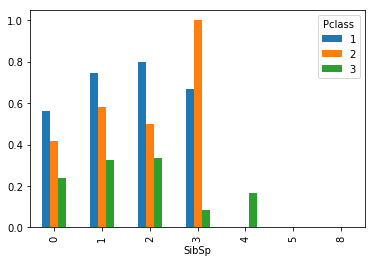

```python
# 显示不同船票类型的不同家庭。
titanic_datas_df.groupby(['SibSp', 'Pclass'])['Survived'].mean().unstack().plot(kind='bar')
```

### 从生存率角度分析：

> 生存率最高：拥有3个家庭关系的船票类型2。（这里只是一个人）

### 家庭关系3到8数据太少，没有可对比性。我们拿家庭关系0到2来对比，没有出现所谓的家庭关系越多死亡率越高说法，反而船票类型为1随着家庭关系越多生存率越高的趋势。

### 结合家庭关系来看，船票类型为1的生存率最高，其次是类型2，再次是类型3。

## 四、结论：

### 对死亡率影响最大因素是船票类型（即社会地位），家庭关系在船票类型1的表现较为突出，年龄较前面两者之间为较少影响因素。

## 局限性：

### 数据集中存在的缺失值，我使用平均值填充缺失值，这样会影响最终结果最小。这里并没有从统计上分析得出这些结果的偶然性，所以并不知道这里的结果是真正的差异造成的还是噪音造成的。该样本的数据还是比较少，而且数据的准确性有待怀疑，导致结论还不能得以证明而且单从数据进行分析我们只可以得到相关性，而不能得到因果性。